# Preparation

```python
# RNN-specific training function
def train_rnn_model(model, train_loader, val_loader, optimizer, criterion, name, num_epochs=10, plot_graphs=True, trial_id=None):
    """
    Train an RNN model that handles variable-length sequences
    """
    scheduler = torch.optim.lr_scheduler.ReduceLROnPlateau(optimizer, mode='max', patience=5, factor=0.5)

    model.to(device)
    best_val_loss = float('inf')
    train_losses = []
    val_losses = []
    train_accs = []
    val_accs = []
    best_epoch = 0

    model_file = f"{name}_trial_{trial_id}_best.pth" if trial_id is not None else f"{name}_best.pth"

    descr = ""
    if trial_id is not None:
        descr = f"Trial {trial_id} - Epochs"
    else:
        descr = "Epochs"

    for epoch in tqdm(range(num_epochs), desc=descr):
        # Training
        model.train()
        train_loss = 0.0
        train_correct = 0
        train_total = 0

        for batch in train_loader:  # Note: 3 values unpacked
            sequences = batch["sequences"].to(device)
            labels = batch["labels"].to(device)
            lengths = batch["lengths"]

            # Zero the parameter gradients
            optimizer.zero_grad()

            # Forward pass with lengths for RNN
            outputs = model(sequences, lengths)
            loss = criterion(outputs, labels)

            # Backward pass and optimize
            loss.backward()

            # Gradient clipping to prevent exploding gradients
            torch.nn.utils.clip_grad_norm_(model.parameters(), max_norm=5.0)

            optimizer.step()

            # Statistics
            train_loss += loss.item()
            _, predicted = torch.max(outputs.data, 1)
            train_total += labels.size(0)
            train_correct += (predicted == labels).sum().item()

        epoch_loss = train_loss / train_total
        epoch_acc = train_correct / train_total
        train_losses.append(epoch_loss)
        train_accs.append(epoch_acc)

        # Validation
        model.eval()
        val_loss = 0.0
        val_correct = 0
        val_total = 0

        with torch.no_grad():
            for batch in val_loader:  # Note: 3 values unpacked
                sequences = batch["sequences"].to(device)
                labels = batch["labels"].to(device)
                lengths = batch["lengths"]

                outputs = model(sequences, lengths)
                loss = criterion(outputs, labels)

                val_loss += loss.item() * sequences.size(0)
                _, predicted = torch.max(outputs.data, 1)
                val_total += labels.size(0)
                val_correct += (predicted == labels).sum().item()

        scheduler.step(val_correct / val_total * 100)

        val_epoch_loss = val_loss / val_total
        val_epoch_acc = val_correct / val_total
        val_losses.append(val_epoch_loss)
        val_accs.append(val_epoch_acc)

        if ((epoch + 1) % 10 == 0 or epoch == num_epochs - 1) and trial_id is None:
            print(f"Epoch {epoch + 1}/{num_epochs} - "
                  f"Train Loss: {epoch_loss:.4f}, Train Acc: {epoch_acc:.4f} - "
                  f"Val Loss: {val_epoch_loss:.4f}, Val Acc: {val_epoch_acc:.4f}")

        if trial_id is None:
            # Save the best model
            if val_epoch_loss < best_val_loss:
                best_val_loss = val_epoch_loss
                torch.save(model.state_dict(), model_file)
                best_epoch = epoch + 1

    if plot_graphs:
        # Plot training curves
        plt.figure(figsize=(12, 4))
        plt.subplot(1, 2, 1)
        plt.plot(train_losses, label='Train')
        plt.plot(val_losses, label='Validation')
        plt.title('Loss vs. Epoch')
        plt.xlabel('Epoch')
        plt.ylabel('Loss')
        plt.legend()

        plt.subplot(1, 2, 2)
        plt.plot(train_accs, label='Train')
        plt.plot(val_accs, label='Validation')
        plt.title('Accuracy vs. Epoch')
        plt.xlabel('Epoch')
        plt.ylabel('Accuracy')
        plt.legend()

        plt.tight_layout()
        plt.show()

    if trial_id is None:
        # Load the best model
        model.load_state_dict(torch.load(model_file))
        print(f"Best model saved at epoch {best_epoch}")
    return model

# RNN-specific evaluation function
def evaluate_rnn_model(model, test_loader, plot_graphs=True, print_report=True):
    """
    Evaluate an RNN model that handles variable-length sequences
    """
    model.eval()
    predictions = []
    true_labels = []

    with torch.no_grad():
        for batch in test_loader:  # Note: 3 values unpacked
            sequences = batch["sequences"].to(device)
            labels = batch["labels"].to(device)
            lengths = batch["lengths"]

            outputs = model(sequences, lengths)
            _, predicted = torch.max(outputs.data, 1)
            predictions.extend(predicted.cpu().numpy())
            true_labels.extend(labels.cpu().numpy())

    if print_report:
        print("\nClassification Report:")
        print(classification_report(true_labels, predictions, zero_division=0))
    if plot_graphs:
        # Plot confusion matrix
        plt.figure(figsize=(4, 3))
        cm = confusion_matrix(true_labels, predictions)
        sns.heatmap(cm, annot=True, fmt='d', cmap='Blues')
        plt.title('Confusion Matrix (Test Set)')
        plt.xlabel('Predicted')
        plt.ylabel('Actual')
        plt.show()

    return classification_report(true_labels, predictions, output_dict=True, zero_division=0)
```

```
Training One-directional RNN:
```

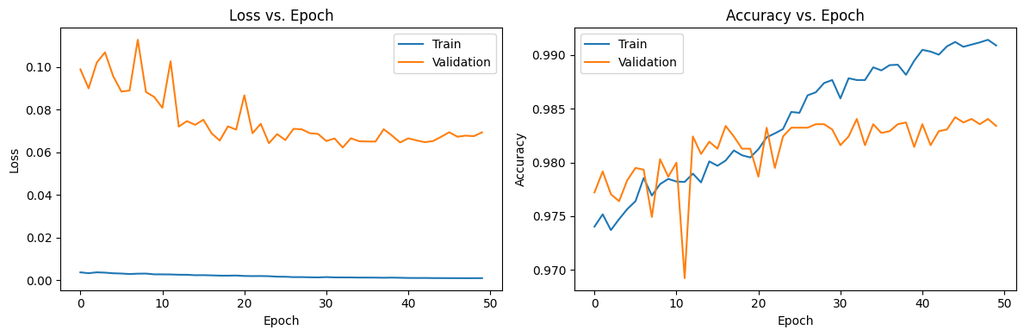

```
Best model saved at epoch 33
```

```python
# Train and evaluate RNN models
print("\nTraining One-directional RNN:")
rnn_model = SimpleRNN(vocab_size=processor.vocab_size, embedding_dim=64, hidden_dim=128, num_layers=2, num_classes=2, dropout=0.3, device=device).to(device)
optimizer_rnn = optim.Adam(rnn_model.parameters(), lr=0.001)
criterion_rnn = nn.CrossEntropyLoss()
start_time = time.time()
rnn_model = train_rnn_model(rnn_model, train_loader_rnn, val_loader_rnn, optimizer_rnn, criterion_rnn, num_epochs=50, name="RNN_One_Directional", plot_graphs=True)
rnn_time = time.time() - start_time
```

```
Training time for One-directional RNN: 463.78 seconds

Classification Report:
              precision    recall  f1-score   support

           0       0.78      0.55      0.64       324
           1       0.99      1.00      0.99     12839

    accuracy                           0.99     13163
   macro avg       0.88      0.77      0.82     13163
weighted avg       0.98      0.99      0.98     13163
```

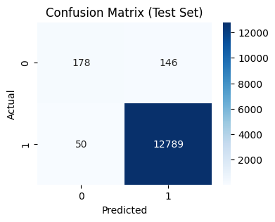

```python
print(f"Training time for One-directional RNN: {rnn_time:.2f} seconds")
rnn_metrics = evaluate_rnn_model(rnn_model, test_loader_rnn)
```

```
Training Bi-directional RNN:
```

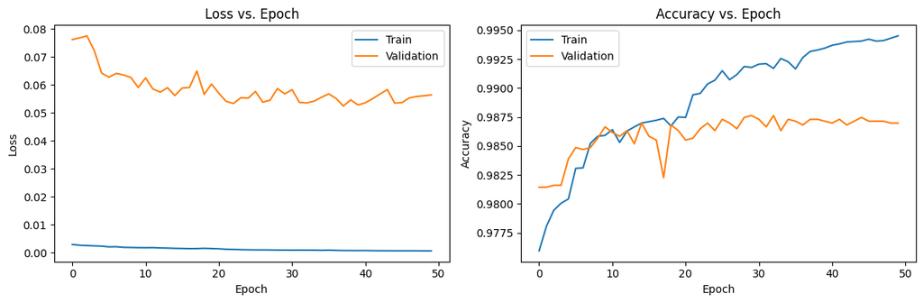

```
Best model saved at epoch 38
```

```python
print("\nTraining Bi-directional RNN:")
birnn_model = BiRNN(vocab_size=processor.vocab_size, embedding_dim=64, hidden_dim=128, num_layers=2, num_classes=2, dropout=0.3, device=device).to(device)
optimizer_birnn = optim.Adam(birnn_model.parameters(), lr=0.001)
start_time = time.time()
birnn_model = train_rnn_model(birnn_model, train_loader_rnn, val_loader_rnn, optimizer_birnn, criterion_rnn, num_epochs=50, name="BiRNN")
birnn_time = time.time() - start_time
```

```
Training time for Bi-directional RNN: 683.75 seconds

Classification Report:
              precision    recall  f1-score   support

           0       0.87      0.69      0.77       324
           1       0.99      1.00      0.99     12839

    accuracy                           0.99     13163
   macro avg       0.93      0.84      0.88     13163
weighted avg       0.99      0.99      0.99     13163
```

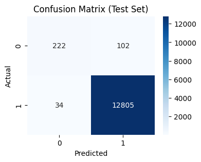

```python
print(f"Training time for Bi-directional RNN: {birnn_time:.2f} seconds")
birnn_metrics = evaluate_rnn_model(birnn_model, test_loader_rnn)
```

```
Training LSTM (Bi-directional):
```

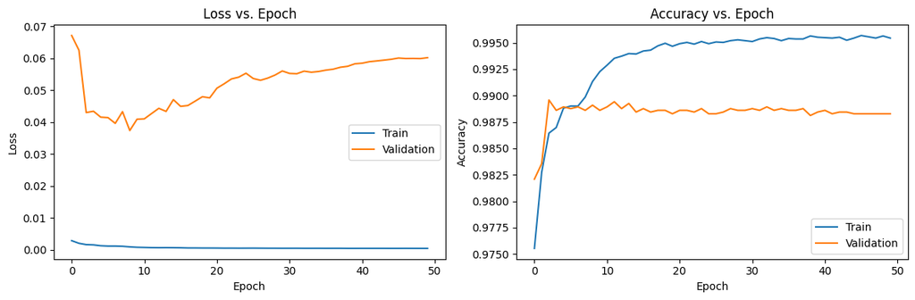

```
Best model saved at epoch 9
```

```python
print("\nTraining LSTM (Bi-directional):")
lstm_model = LSTMModel(vocab_size=processor.vocab_size, embedding_dim=64, hidden_dim=128, num_layers=2, num_classes=2, dropout=0.3, bidirectional=True, device=device).to(device)
optimizer_lstm = optim.Adam(lstm_model.parameters(), lr=0.001)
start_time = time.time()
lstm_model = train_rnn_model(lstm_model, train_loader_rnn, val_loader_rnn, optimizer_lstm, criterion_rnn, num_epochs=50, name="LSTM")
lstm_time = time.time() - start_time
```

```
Training time: 728.78 seconds


Classification Report:
              precision    recall  f1-score   support

           0       0.90      0.72      0.80       324
           1       0.99      1.00      1.00     12839

    accuracy                           0.99     13163
   macro avg       0.95      0.86      0.90     13163
weighted avg       0.99      0.99      0.99     13163
```

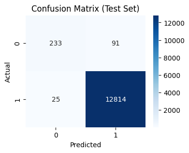

```python
print(f"Training time: {lstm_time:.2f} seconds \n")
lstm_metrics = evaluate_rnn_model(lstm_model, test_loader_rnn)
```

```python
# Comparison table for RNN results
comparison_data = {
    "Model": ["Simple RNN", "Bi-directional RNN", "Bi-directional LSTM"],
    "Accuracy": [rnn_metrics['accuracy'], birnn_metrics['accuracy'], lstm_metrics['accuracy']],
    "Precision": [rnn_metrics['weighted avg']['precision'], birnn_metrics['weighted avg']['precision'], lstm_metrics['weighted avg']['precision']],
    "Recall": [rnn_metrics['weighted avg']['recall'], birnn_metrics['weighted avg']['recall'], lstm_metrics['weighted avg']['recall']],
    "F1 Score": [rnn_metrics['weighted avg']['f1-score'], birnn_metrics['weighted avg']['f1-score'], lstm_metrics['weighted avg']['f1-score']],
}
comparison_df = pd.DataFrame(comparison_data)
# Display the comparison table
print(comparison_df)
```

```
                 Model  Accuracy  Precision    Recall  F1 Score
0           Simple RNN  0.985110   0.983593  0.985110  0.983843
1   Bi-directional RNN  0.989668   0.989023  0.989668  0.989076
2  Bi-directional LSTM  0.991187   0.990737  0.991187  0.990699
```

```
Training One-directional RNN with Class Weights:
```

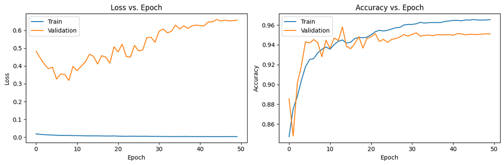

```
Best model saved at epoch 9
RNN Training time with Class Weights: 466.91 seconds

Classification Report:
              precision    recall  f1-score   support

           0       0.29      0.81      0.43       324
           1       0.99      0.95      0.97     12839

    accuracy                           0.95     13163
   macro avg       0.64      0.88      0.70     13163
weighted avg       0.98      0.95      0.96     13163
```

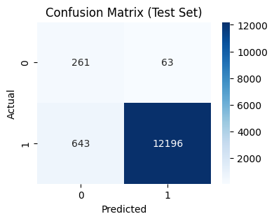

```python
class_weights_tensor = torch.FloatTensor(class_weights).to(device)

# Update your weighted criterion
weighted_criterion_logits = nn.CrossEntropyLoss(weight=class_weights_tensor, reduction='mean').to(device)

print("\nTraining One-directional RNN with Class Weights:")
rnn_model_weighted = SimpleRNN(vocab_size=processor.vocab_size, embedding_dim=64, hidden_dim=128, num_layers=2, num_classes=2, dropout=0.3, device=device).to(device)
optimizer_rnn_weighted = optim.Adam(rnn_model_weighted.parameters(), lr=0.001)

start_time = time.time()
rnn_model_weighted = train_rnn_model(rnn_model_weighted, train_loader_rnn, val_loader_rnn, optimizer_rnn_weighted, weighted_criterion_logits, num_epochs=50, name="SimpleRNN_Weighted")
rnn_weighted_time = time.time() - start_time
print(f"RNN Training time with Class Weights: {rnn_weighted_time:.2f} seconds")
rnn_weighted_metrics = evaluate_rnn_model(rnn_model_weighted, test_loader_rnn)
```

```
Training Bi-directional RNN with Class Weights:
```

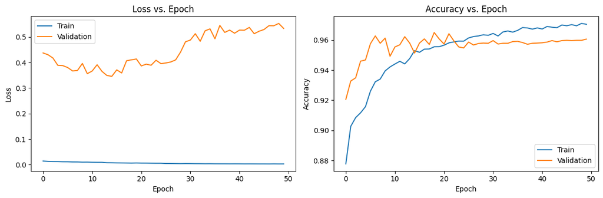

```
Best model saved at epoch 15
```

```python
print("\nTraining Bi-directional RNN with Class Weights:")
birnn_model_weighted = BiRNN(vocab_size=processor.vocab_size, embedding_dim=64, hidden_dim=128, num_layers=2, num_classes=2, dropout=0.3, device=device).to(device)
optimizer_birnn_weighted = optim.Adam(birnn_model_weighted.parameters(), lr=0.001)

start_time = time.time()
birnn_model_weighted = train_rnn_model(birnn_model_weighted, train_loader_rnn, val_loader_rnn,
                                       optimizer_birnn_weighted, weighted_criterion_logits, num_epochs=50, name="BiRNN_Weighted")
birnn_weighted_time = time.time() - start_time
```

```
BiRNN Training time with Class Weights: 682.60 seconds

Classification Report:
              precision    recall  f1-score   support

           0       0.36      0.78      0.50       324
           1       0.99      0.97      0.98     12839

    accuracy                           0.96     13163
   macro avg       0.68      0.87      0.74     13163
weighted avg       0.98      0.96      0.97     13163
```

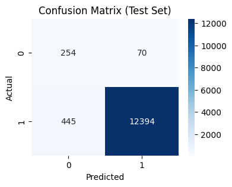

```python
print(f"BiRNN Training time with Class Weights: {birnn_weighted_time:.2f} seconds")
birnn_weighted_metrics = evaluate_rnn_model(birnn_model_weighted, test_loader_rnn)
```

```
Training LSTM (Bi-directional) with Class Weights:
```

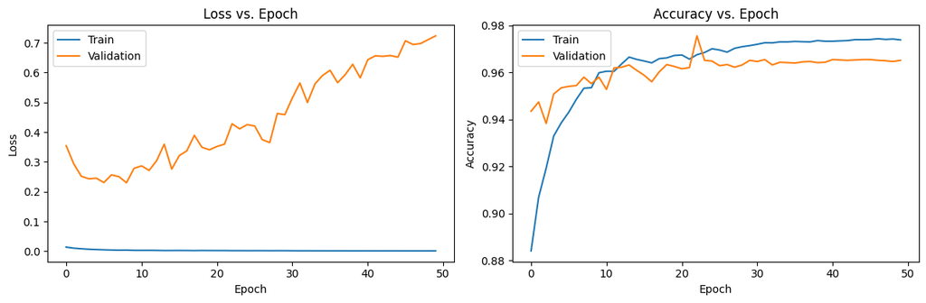

```
Best model saved at epoch 9
```

```python
print("\nTraining LSTM (Bi-directional) with Class Weights:")
lstm_model_weighted = LSTMModel(vocab_size=processor.vocab_size, embedding_dim=64, hidden_dim=128, num_layers=2, num_classes=2, dropout=0.3, bidirectional=True, device=device).to(device)
optimizer_lstm_weighted = optim.Adam(lstm_model_weighted.parameters(), lr=0.001)

start_time = time.time()
lstm_model_weighted = train_rnn_model(lstm_model_weighted, train_loader_rnn, val_loader_rnn, optimizer_lstm_weighted,
                                      weighted_criterion_logits, num_epochs=50, name="LSTM_Weighted")
lstm_weighted_time = time.time() - start_time
```

```
LSTM Training time with Class Weights: 730.84 seconds

Classification Report:
              precision    recall  f1-score   support

           0       0.47      0.86      0.61       324
           1       1.00      0.98      0.99     12839

    accuracy                           0.97     13163
   macro avg       0.73      0.92      0.80     13163
weighted avg       0.98      0.97      0.98     13163
```

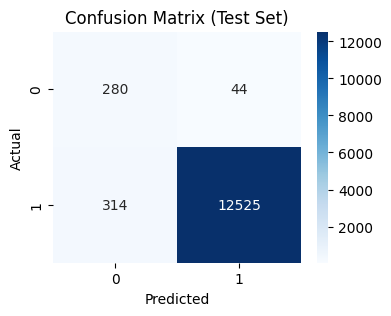

```python
print(f"LSTM Training time with Class Weights: {lstm_weighted_time:.2f} seconds")
lstm_weighted_metrics = evaluate_rnn_model(lstm_model_weighted, test_loader_rnn)
```

```python
# Comparison table for weighted RNN results
weighted_comparison_data = {
    "Model": ["Simple RNN (Weighted)", "Bi-directional RNN (Weighted)", "Bi-directional LSTM (Weighted)"],
    "Accuracy": [
        rnn_weighted_metrics['accuracy'], birnn_weighted_metrics['accuracy'],
        lstm_weighted_metrics['accuracy']
    ],
    "Precision": [
        rnn_weighted_metrics['weighted avg']['precision'], birnn_weighted_metrics['weighted avg']['precision'],
        lstm_weighted_metrics['weighted avg']['precision']
    ],
    "Recall": [
        rnn_weighted_metrics['weighted avg']['recall'], birnn_weighted_metrics['weighted avg']['recall'],
        lstm_weighted_metrics['weighted avg']['recall']
    ],
    "F1 Score": [
        rnn_weighted_metrics['weighted avg']['f1-score'], birnn_weighted_metrics['weighted avg']['f1-score'],
        lstm_weighted_metrics['weighted avg']['f1-score']
    ],
    "Training Time (s)": [rnn_weighted_time, birnn_weighted_time, lstm_weighted_time]
}

weighted_comparison_df = pd.DataFrame(weighted_comparison_data)

# Compare with non-weighted RNN models
combined_comparison_data = {
    "Model": ["Simple RNN", "Bi-directional RNN", "Bi-directional LSTM",
              "Simple RNN (Weighted)", "Bi-directional RNN (Weighted)", "Bi-directional LSTM (Weighted)"],
    "Accuracy": [
        rnn_metrics['accuracy'], birnn_metrics['accuracy'],
        lstm_metrics['accuracy'], rnn_weighted_metrics['accuracy'],
        birnn_weighted_metrics['accuracy'], lstm_weighted_metrics['accuracy']
    ],
    "Precision": [
        rnn_metrics['weighted avg']['precision'], birnn_metrics['weighted avg']['precision'],
        lstm_metrics['weighted avg']['precision'], rnn_weighted_metrics['weighted avg']['precision'],
        birnn_weighted_metrics['weighted avg']['precision'], lstm_weighted_metrics['weighted avg']['precision']
    ],
    "Recall": [
        rnn_metrics['weighted avg']['recall'], birnn_metrics['weighted avg']['recall'],
        lstm_metrics['weighted avg']['recall'], rnn_weighted_metrics['weighted avg']['recall'],
        birnn_weighted_metrics['weighted avg']['recall'], lstm_weighted_metrics['weighted avg']['recall']
    ],
    "F1 Score": [
        rnn_metrics['weighted avg']['f1-score'], birnn_metrics['weighted avg']['f1-score'],
        lstm_metrics['weighted avg']['f1-score'], rnn_weighted_metrics['weighted avg']['f1-score'],
        birnn_weighted_metrics['weighted avg']['f1-score'], lstm_weighted_metrics['weighted avg']['f1-score']
    ],
    "Training Time (s)": [
        rnn_time, birnn_time, lstm_time,
        rnn_weighted_time, birnn_weighted_time, lstm_weighted_time
    ]
}

combined_comparison_df = pd.DataFrame(combined_comparison_data)

# Display the comparison table
print("\nComparison of all RNN models:")
print(combined_comparison_df)
```

```
Comparison of all RNN models:
                            Model  Accuracy  Precision    Recall  F1 Score  \
0                      Simple RNN  0.985110   0.983593  0.985110  0.983843
1              Bi-directional RNN  0.989668   0.989023  0.989668  0.989076
2             Bi-directional LSTM  0.991187   0.990737  0.991187  0.990699
3           Simple RNN (Weighted)  0.946365   0.977480  0.946365  0.958411
4   Bi-directional RNN (Weighted)  0.960875   0.978852  0.960875  0.967756
5  Bi-directional LSTM (Weighted)  0.972803   0.983574  0.972803  0.976658

   Training Time (s)
0         463.783360
1         683.752319
2         728.782056
3         466.907269
4         682.602933
5         730.839736
```

```python
# Compare precision, recall, and F1-score for label 0.0 across all RNN models
rnns_metrics = {
    "Model": ["Simple RNN", "Bi-directional RNN", "Bi-directional LSTM",
              "Simple RNN (Weighted)", "Bi-directional RNN (Weighted)", "Bi-directional LSTM (Weighted)"],
    "Precision (0)": [
        rnn_metrics['0']['precision'], birnn_metrics['0']['precision'],
        lstm_metrics['0']['precision'], rnn_weighted_metrics['0']['precision'],
        birnn_weighted_metrics['0']['precision'], lstm_weighted_metrics['0']['precision']
    ],
    "Recall (0)": [
        rnn_metrics['0']['recall'], birnn_metrics['0']['recall'],
        lstm_metrics['0']['recall'], rnn_weighted_metrics['0']['recall'],
        birnn_weighted_metrics['0']['recall'], lstm_weighted_metrics['0']['recall']
    ],
    "F1-Score (0)": [
        rnn_metrics['0']['f1-score'], birnn_metrics['0']['f1-score'],
        lstm_metrics['0']['f1-score'], rnn_weighted_metrics['0']['f1-score'],
        birnn_weighted_metrics['0']['f1-score'], lstm_weighted_metrics['0']['f1-score']
    ]
}
# Create a DataFrame for better visualization
rnn_comparison_df = pd.DataFrame(rnns_metrics)
# Display the comparison table
print(rnn_comparison_df)
```

```
                            Model  Precision (0)  Recall (0)  F1-Score (0)
0                      Simple RNN       0.780702    0.549383      0.644928
1              Bi-directional RNN       0.867188    0.685185      0.765517
2             Bi-directional LSTM       0.903101    0.719136      0.800687
3           Simple RNN (Weighted)       0.288717    0.805556      0.425081
4   Bi-directional RNN (Weighted)       0.363376    0.783951      0.496579
5  Bi-directional LSTM (Weighted)       0.471380    0.864198      0.610022
```

## 3.1 Optimize RNN

```python
# Updated objective function with proper dropout handling
def objective(trial):
    # Define the hyperparameter space
    embedding_dim = trial.suggest_categorical('embedding_dim', [16, 32, 64, 128])
    hidden_dim = trial.suggest_categorical('hidden_dim', [64, 128, 256])
    dropout_rate = trial.suggest_float('dropout_rate', 0.1, 0.5)
    learning_rate = trial.suggest_float('learning_rate', 1e-5, 1e-2, log=True)
    batch_size = trial.suggest_categorical('batch_size', [32, 64, 128])
    num_layers = trial.suggest_int('num_layers', 1, 4)

    # Create the model with proper dropout handling
    lstm_model = LSTMModel( vocab_size=processor.vocab_size,  embedding_dim=embedding_dim,  hidden_dim=hidden_dim, dropout=dropout_rate, num_layers=num_layers, device=device).to(device)
    optimizer = torch.optim.Adam(lstm_model.parameters(), lr=learning_rate)

    t_lstm_train_loader = DataLoader(train_dataset_rnn, batch_size=batch_size, shuffle=False, collate_fn=collate_fn)
    t_lstm_val_loader = DataLoader(val_dataset_rnn, batch_size=batch_size, shuffle=False, collate_fn=collate_fn)
    t_lstm_test_loader = DataLoader(test_dataset_rnn, batch_size=batch_size, shuffle=False, collate_fn=collate_fn)

    # Train the model
    lstm_model = train_rnn_model(lstm_model, t_lstm_train_loader, t_lstm_val_loader,
                                  optimizer, criterion_rnn, num_epochs=20,
                                  name="LSTM_Embeddings_opt", plot_graphs=False,
                                  trial_id=trial.number)

    # Evaluate the model
    metrics = evaluate_rnn_model(lstm_model, t_lstm_test_loader, plot_graphs=False, print_report=False)

    # Return the F1-score for label 0.0 as the objective to maximize
    return metrics['0']['f1-score']

# Run Optuna with parallel trials
start_time = time.time()

# Create a pruning study
study = optuna.create_study(direction='maximize', study_name="optimize_rnn")

# Run the optimization
study.optimize(objective, n_trials=30, n_jobs=-1)

# Report results
elapsed_time = time.time() - start_time
print(f"\n=== Optimization completed in {elapsed_time:.2f} seconds ===")
print(f"Best trial: {study.best_trial.number}")
print(f"Best F1-score: {study.best_value:.4f}")
print("Best hyperparameters:")
for key, value in study.best_params.items():
    print(f"  {key}: {value}")
```

```
[I 2025-08-14 16:56:05,766] A new study created in memory with name: optimize_rnn







































```

[output cut: 455 more lines]

```










[I 2025-08-14 19:17:24,582] Trial 26 finished with value: 0.6917562724014337 and parameters: {'embedding_dim': 64, 'hidden_dim': 64, 'dropout_rate': 0.2415994081355199, 'learning_rate': 0.0001439342168606684, 'batch_size': 64, 'num_layers': 2}. Best is trial 5 with value: 0.8069565217391304.
[I 2025-08-14 19:17:29,679] Trial 27 finished with value: 0.7508650519031143 and parameters: {'embedding_dim': 16, 'hidden_dim': 64, 'dropout_rate': 0.38497706154474204, 'learning_rate': 0.0011994099288654754, 'batch_size': 64, 'num_layers': 2}. Best is trial 5 with value: 0.8069565217391304.


[I 2025-08-14 19:25:37,209] Trial 29 finished with value: 0.4876957494407159 and parameters: {'embedding_dim': 16, 'hidden_dim': 64, 'dropout_rate': 0.43536031531691255, 'learning_rate': 0.0011666476370365637, 'batch_size': 64, 'num_layers': 4}. Best is trial 5 with value: 0.8069565217391304.
```

```
=== Optimization completed in 8971.45 seconds ===
Best trial: 5
Best F1-score: 0.8070
Best hyperparameters:
  embedding_dim: 128
  hidden_dim: 64
  dropout_rate: 0.33776949304541526
  learning_rate: 0.0054025910594576515
  batch_size: 64
  num_layers: 4
```

```
Training LSTM with best hyperparameters:
```

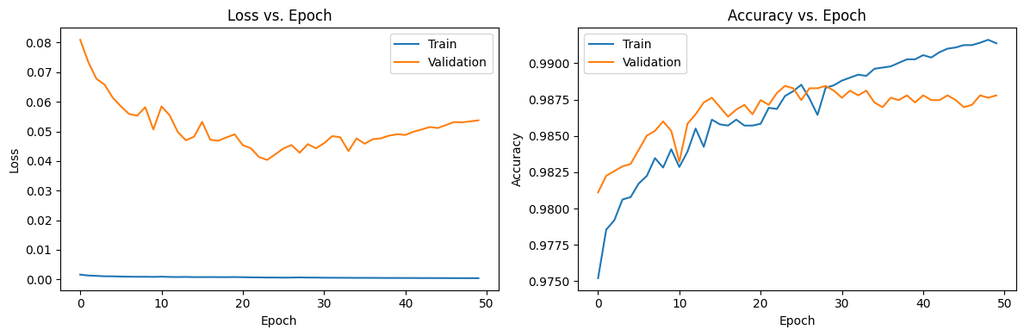

```
Best model saved at epoch 24
```

```python
# Initialize the model with the best hyperparameters
best_lstm_model = LSTMModel( vocab_size=processor.vocab_size,
                                   embedding_dim=study.best_params['embedding_dim'],
                                   hidden_dim=study.best_params['hidden_dim'],
                                   dropout=study.best_params['dropout_rate'],
                                   num_layers=study.best_params['num_layers'], device=device).to(device)

# Create optimizer with the best learning rate
best_optimizer = torch.optim.Adam(best_lstm_model.parameters(), lr=study.best_params['learning_rate'])

# Create data loaders with the best batch size
best_rnn_batch_size = study.best_params['batch_size']
best_rnn_train_loader = DataLoader(train_dataset_rnn, batch_size=best_rnn_batch_size, shuffle=False, collate_fn=collate_fn)
best_rnn_val_loader = DataLoader(val_dataset_rnn, batch_size=best_rnn_batch_size, shuffle=False, collate_fn=collate_fn)
best_rnn_test_loader = DataLoader(test_dataset_rnn, batch_size=best_rnn_batch_size, shuffle=False, collate_fn=collate_fn)

# Train the model with the best number of epochs
print("\nTraining LSTM with best hyperparameters:")
best_lstm_model = train_rnn_model(best_lstm_model, best_rnn_train_loader,
                             best_rnn_val_loader, best_optimizer, criterion_rnn,
                             num_epochs=50, name="LSTM_Best", plot_graphs=True)
```

```
Classification Report:
              precision    recall  f1-score   support

           0       0.91      0.64      0.75       324
           1       0.99      1.00      0.99     12839

    accuracy                           0.99     13163
   macro avg       0.95      0.82      0.87     13163
weighted avg       0.99      0.99      0.99     13163
```

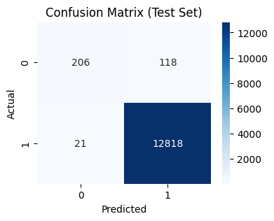

```python
# Evaluate the model
best_lstm_metrics = evaluate_rnn_model(best_lstm_model, best_rnn_test_loader)
```

# Task 4: Graph Neural Network

Finally, use a Graph Neural Network (GNN) to model your problem. Consider each sequence of API call as a graph.

- Do you still have to pad your data? If yes, how?
- Do you have to truncate the testing sequences? Justify your answer with your understanding of why it is/it is not the case.
- What is the advantage of modelling your problem with a GNN with respect to FFNN and RNN? What do you lose?
- Start creating a first simple GCN and train/test it on CPU first and GPU next. How long does it take for training and testing in each configuration? How does it differ with respect to previous architectures? Can you guess why?
- Finally train and tune variations of GNN considering different message and aggregation functions and architectures:
  - Simple GCN
  - GraphSAGE
  - and GAT

```python
from torch_geometric.data import Data, Dataset
from torch_geometric.loader import DataLoader as GeoDataLoader
from torch_geometric.nn import GCNConv, SAGEConv, GATConv, GATv2Conv, AttentionalAggregation, global_mean_pool
import networkx as nx
from torch_geometric.utils import to_networkx
```

```python
class APIGraphDataset(Dataset):
    def __init__(self, samples, vocab_dict, oov_token="<UNK>"):
        self.graphs = []
        self.vocab_dict = vocab_dict
        self.oov_index = vocab_dict[oov_token]

        for sample in samples:
            sequence = sample["api_call_sequence"]
            label = sample["is_malware"]

            node_ids = [vocab_dict.get(api, self.oov_index) for api in sequence]

            x = torch.nn.functional.one_hot(torch.tensor(node_ids), num_classes=len(vocab_dict)).float()

            edges = [(i, i + 1) for i in range(len(node_ids) - 1)]
            if edges:
                edge_index = torch.tensor(edges, dtype=torch.long).t().contiguous()
            else:
                edge_index = torch.empty((2, 0), dtype=torch.long)

            y = torch.tensor([label], dtype=torch.long)
            assert edge_index.max().item() < x.size(0) if edge_index.numel() > 0 else True, \
                "edge_index refers to non-existent node index in x"

            data = Data(x=x, edge_index=edge_index, y=y)
            self.graphs.append(data)

    def __len__(self):
        return len(self.graphs)

    def __getitem__(self, idx):
        return self.graphs[idx]
```

```python
def create_gnn_vocab(df, oov_token="<UNK>"):
    vocab = set(api for seq in df["api_call_sequence"] for api in seq)
    vocab_dict = {api: idx for idx, api in enumerate(sorted(vocab))}
    vocab_dict[oov_token] = len(vocab_dict)
    return vocab_dict
```

```python
gnn_vocab = create_gnn_vocab(train_df, oov_token="<UNK>")
```

```python
gnn_train_data = train_df.to_dict(orient="records")
gnn_val_data = val_df.to_dict(orient="records")
gnn_test_data = test_df.to_dict(orient="records")

train_gnn_dataset = APIGraphDataset(gnn_train_data, gnn_vocab)
val_gnn_dataset = APIGraphDataset(gnn_val_data, gnn_vocab)
test_gnn_dataset = APIGraphDataset(gnn_test_data, gnn_vocab)

# Create data loaders
graph_train_loader = GeoDataLoader(train_gnn_dataset, batch_size=BATCH_SIZE)
graph_val_loader = GeoDataLoader(val_gnn_dataset, batch_size=BATCH_SIZE)
graph_test_loader = GeoDataLoader(test_gnn_dataset, batch_size=BATCH_SIZE)

print(train_gnn_dataset[1])

print(f"train dataset length: {len(train_gnn_dataset)}  validation dataset length: {len(test_gnn_dataset)}")
```

```
Data(x=[73, 249], edge_index=[2, 72], y=[1])
train dataset length: 24570  validation dataset length: 13163
```

```python
def plot_graphs_side_by_side(data1, data2, show_features=False, layout_k=0.7, titles=None):
    """
    Plot two PyTorch Geometric graphs side by side using networkx with updated styling.
    Node color changed to green.
    """
    graphs = [data1, data2]
    default_titles = ["Long Graph", "Short Graph"]
    if titles and len(titles) == 2:
        default_titles = titles

    fig, axes = plt.subplots(1, 2, figsize=(14, 6), facecolor="#1e1e24")

    for idx, (data, ax) in enumerate(zip(graphs, axes)):
        G = to_networkx(data, to_undirected=True)
        pos = nx.spring_layout(G, seed=42, k=layout_k)

        if show_features:
            node_labels = {
                i: "[" + ", ".join(f"{v:.1f}" for v in data.x[i].tolist()) + "]"
                for i in range(data.x.size(0))
            }
        else:
            node_labels = {i: str(i) for i in range(data.x.size(0))}

        node_sizes = [450 + 15 * deg for _, deg in G.degree()]  # keep degree-based sizing

        nx.draw_networkx_nodes(
            G, pos, ax=ax,
            node_size=node_sizes,
            node_color="#2ecc71",   # solid green color
            alpha=0.9,
            linewidths=1.5,
            edgecolors="#f4f4f4"
        )

        nx.draw_networkx_edges(
            G, pos, ax=ax,
            width=1.8,
            edge_color="#b37622",
            style='solid',
            alpha=0.8,
            arrows=False
        )

        nx.draw_networkx_labels(
            G, pos, labels={k: v for k, v in node_labels.items()},
            font_size=8, font_color="#ffffff", font_weight='bold', ax=ax
        )

        if show_features:
            offset = 0.07
            pos_shifted = {k: (v[0], v[1] + offset) for k, v in pos.items()}
            nx.draw_networkx_labels(
                G, pos_shifted,
                labels=node_labels,
                font_size=6,
                font_color="#a88738",
                ax=ax
            )

        if hasattr(data, "edge_attr") and data.edge_attr is not None:
            edge_labels = {
                (u, v): "[" + ", ".join(f"{e:.2f}" for e in data.edge_attr[i].tolist()) + "]"
                for i, (u, v) in enumerate(data.edge_index.t().tolist())
            }
            nx.draw_networkx_edge_labels(
                G, pos, edge_labels=edge_labels,
                font_size=6, font_color="#8ecae6", ax=ax
            )

        ax.set_title(default_titles[idx], color="#fafafa", fontsize=12, pad=10)
        ax.set_axis_off()
        ax.set_facecolor("#2a2e37")

    plt.tight_layout()
    plt.show()
    return fig, axes
```

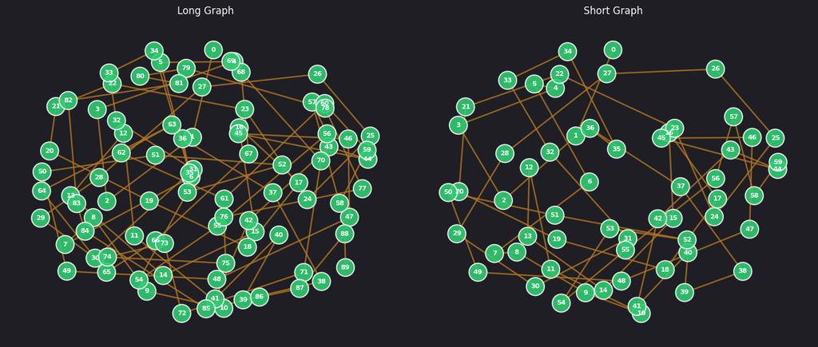

```
(<Figure size 1400x600 with 2 Axes>,
 array([<Axes: title={'center': 'Long Graph'}>,
        <Axes: title={'center': 'Short Graph'}>], dtype=object))
```

```python
longest_graph = max(train_gnn_dataset, key=lambda g: g.num_nodes)
shortest_graph = min(train_gnn_dataset, key=lambda g: g.num_nodes)

plot_graphs_side_by_side(longest_graph, shortest_graph)
```

```python
#GCN Model
class GCN(torch.nn.Module):
    def __init__(self, input_dim, hidden_dim, output_dim):
        super(GCN, self).__init__()
        self.conv1 = GCNConv(input_dim, hidden_dim)
        self.conv2 = GCNConv(hidden_dim, hidden_dim)
        self.fc = torch.nn.Linear(hidden_dim, output_dim)

    def forward(self, data):
        x, edge_index, batch = data.x, data.edge_index, data.batch
        x = F.relu(self.conv1(x, edge_index))
        x = F.relu(self.conv2(x, edge_index))
        x = global_mean_pool(x, batch)  # Aggregate node features. From Node to Graph Features
        x = self.fc(x)
        return x

#GraphSAGE Model
class GraphSAGE(torch.nn.Module):
    def __init__(self, input_dim, hidden_dim, output_dim):
        super(GraphSAGE, self).__init__()
        self.conv1 = SAGEConv(input_dim, hidden_dim)
        self.conv2 = SAGEConv(hidden_dim, hidden_dim)
        self.fc = torch.nn.Linear(hidden_dim, output_dim)

    def forward(self, data):
        x, edge_index, batch = data.x, data.edge_index, data.batch
        x = F.relu(self.conv1(x, edge_index))
        x = F.relu(self.conv2(x, edge_index))
        x = global_mean_pool(x, batch)# Aggregate node features. From Node to Graph Features
        x = self.fc(x)
        return x

#GAT Model (Graph Attention Network)
class GAT(torch.nn.Module):
    def __init__(self, input_dim, hidden_dim, output_dim, heads=8):
        super(GAT, self).__init__()
        self.conv1 = GATConv(input_dim, hidden_dim, heads=heads, concat=True)
        self.conv2 = GATConv(hidden_dim * heads, hidden_dim, heads=1, concat=False)
        self.fc = torch.nn.Linear(hidden_dim, output_dim)

    def forward(self, data):
        x, edge_index, batch = data.x, data.edge_index, data.batch
        x = F.elu(self.conv1(x, edge_index))
        x = F.elu(self.conv2(x, edge_index))
        x = global_mean_pool(x, batch) # Aggregate node features. From Node to Graph Features
        x = self.fc(x)
        return x


# Training function for GNN models
def train_gnn(model, train_loader, val_loader, optimizer, criterion, device, num_epochs=10, name="GNN", plot_graphs=True, trial_id=None):
    """
    Train a GNN model
    """
    model.to(device)
    best_val_loss = float('inf')
    train_losses = []
    val_losses = []
    train_accs = []
    val_accs = []
    best_epoch = 0

    model_path = f"{name}_trial_{trial_id}_best.pth" if trial_id is not None else f"{name}_best.pth"

    descr = ""
    if trial_id is not None:
        descr = f"Trial {trial_id} - Epochs"
    else:
        descr = "Epochs"

    # Get dataset sizes for proper loss calculation
    train_dataset_size = len(train_loader.dataset)
    val_dataset_size = len(val_loader.dataset)

    for epoch in tqdm(range(num_epochs), desc=descr):
        # Training
        model.train()
        total_train_loss = 0
        correct = 0
        total = 0

        for batch in train_loader:
            batch = batch.to(device)
            optimizer.zero_grad()

            # Forward pass
            outputs = model(batch)
            loss = criterion(outputs, batch.y.view(-1))

            # Backward pass and optimize
            loss.backward()
            optimizer.step()

            # Statistics
            total_train_loss += loss.item() * batch.num_graphs
            _, predicted = torch.max(outputs.data, 1)
            total += batch.num_graphs
            correct += (predicted == batch.y.view(-1)).sum().item()

        # Calculate average loss using dataset size
        epoch_loss = total_train_loss / train_dataset_size
        epoch_acc = correct / total
        train_losses.append(epoch_loss)
        train_accs.append(epoch_acc)

        # Validation
        model.eval()
        total_val_loss = 0
        val_correct = 0
        val_total = 0

        with torch.no_grad():
            for batch in val_loader:
                batch = batch.to(device)
                outputs = model(batch)
                loss = criterion(outputs, batch.y.view(-1))

                total_val_loss += loss.item() * batch.num_graphs
                _, predicted = torch.max(outputs.data, 1)
                val_total += batch.num_graphs
                val_correct += (predicted == batch.y.view(-1)).sum().item()

        # Calculate average loss using dataset size
        val_epoch_loss = total_val_loss / val_dataset_size
        val_epoch_acc = val_correct / val_total
        val_losses.append(val_epoch_loss)
        val_accs.append(val_epoch_acc)

        if (epoch + 1) % 10 == 0 or epoch == num_epochs - 1:
            if trial_id is None:
                tqdm.write(f'Epoch {epoch+1}/{num_epochs}, Train Loss: {epoch_loss:.4f}, Train Acc: {epoch_acc:.4f}, Val Loss: {val_epoch_loss:.4f}, Val Acc: {val_epoch_acc:.4f}')

        if trial_id is None:
            # Save the best model
            if val_epoch_loss < best_val_loss:
                best_val_loss = val_epoch_loss
                best_epoch = epoch + 1
                torch.save(model.state_dict(), model_path)

    if plot_graphs:
        # Plot training curves
        plt.figure(figsize=(12, 4))
        plt.subplot(1, 2, 1)
        plt.plot(train_losses, label='Train')
        plt.plot(val_losses, label='Validation')
        plt.title('Loss vs. Epoch')
        plt.xlabel('Epoch')
        plt.ylabel('Loss')
        plt.legend()

        plt.subplot(1, 2, 2)
        plt.plot(train_accs, label='Train')
        plt.plot(val_accs, label='Validation')
        plt.title('Accuracy vs. Epoch')
        plt.xlabel('Epoch')
        plt.ylabel('Accuracy')
        plt.legend()

        plt.tight_layout()
        plt.show()

    if trial_id is None:
        # Load the best model
        model.load_state_dict(torch.load(model_path))
        print(f"Best model saved at epoch {best_epoch} with validation loss {best_val_loss:.4f}")

    return model

# Evaluation function for GNN models
def evaluate_gnn(model, test_loader, device, plot_graphs=True, print_report=True):
    """
    Evaluate a GNN model
    """
    model.eval()
    predictions = []
    true_labels = []

    with torch.no_grad():
        for data in test_loader:
            data = data.to(device)
            out = model(data)
            _, predicted = torch.max(out.data, 1)  # Get the class with highest probability

            predictions.extend(predicted.cpu().numpy())
            true_labels.extend(data.y.view(-1).cpu().numpy())

    if print_report:
        print("\nClassification Report:")
        print(classification_report(true_labels, predictions, zero_division=0))

    if plot_graphs:
      # Plot confusion matrix
      plt.figure(figsize=(4, 3))
      cm = confusion_matrix(true_labels, predictions)
      sns.heatmap(cm, annot=True, fmt='d', cmap='Blues')
      plt.title('Confusion Matrix (Test Set)')
      plt.xlabel('Predicted')
      plt.ylabel('Actual')
      plt.show()

    return classification_report(true_labels, predictions, output_dict=True, zero_division=0)
```

```
Training GCN on CPU:
```

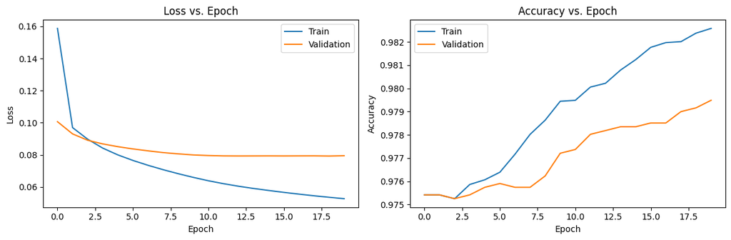

```
Best model saved at epoch 19 with validation loss 0.0793
```

```python
# Train GNN models on CPU first
print("\nTraining GCN on CPU:")
device = torch.device('cpu')
input_dim = train_gnn_dataset[0].x.shape[1]
gcn_model = GCN(input_dim=input_dim, hidden_dim=64, output_dim=2).to(device)
optimizer_gcn = optim.Adam(gcn_model.parameters(), lr=0.001)
cpu_device = torch.device('cpu')

# Use BCEWithLogitsLoss for better numerical stability
criterion = nn.CrossEntropyLoss().to(cpu_device)

start_time = time.time()
gcn_model = train_gnn(gcn_model, graph_train_loader, graph_val_loader, optimizer_gcn,
                      criterion, cpu_device, num_epochs=20, name="GCN")
cpu_training_time = time.time() - start_time
```